# Assignment 6: Visualization - Aesthetic Mapping

*How to do it?*:

- Open the Rmarkdown file of this assignment (link) in Rstudio.
- Right under each **question**, insert a code chunk (you can use the hotkey `Ctrl + Alt + I` to add a code chunk) and code the solution for the question.
- `Knit` the rmarkdown file (hotkey: `Ctrl + Alt + K`) to export an html.
- Publish the html file to your Githiub Page.

*Submission*: Submit the link on Github of the assignment to Canvas.

### Questions on Your Selected Data

Choose a dataset and produce the following types of plots and comment on each plot. Plots should be meaningful. If you use the data we used in class, make sure the plots are not the same as the ones in the slides.

```r
#Load packages.
library(tidyverse)
library(ggplot2)

#Set working directory where data set is contained.
setwd('C:\\Users\\student\\OneDrive - Bryant University\\2023-2024\\Semester 1\\MATH421-A Statistical Analysis with R\\Data')

#read the data
df <- read_csv('adult_census.csv')
```

1. For one continuous variable:
- Density

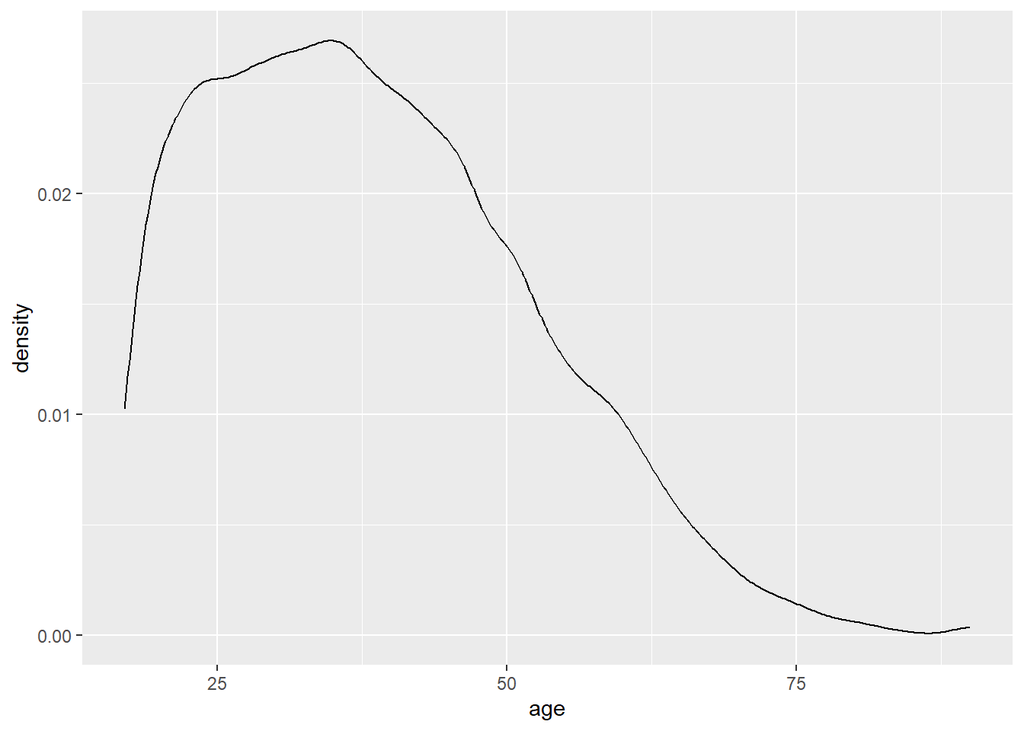

```r
df %>% ggplot()+
  geom_density(mapping = aes(x = age))
```

```r
#The density plot for the variable age in the adult census data shows that age is right (positively) skewed.This suggests that there are more younger subjects in the dataset, specifically more people below the age of 50. After 50, the number of older subjects declines.
```

- Histogram

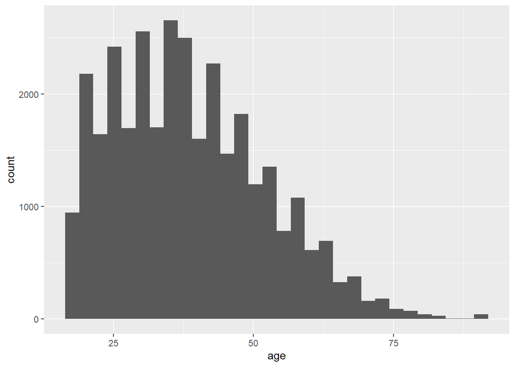

```r
df %>% ggplot()+
  geom_histogram(mapping = aes(x = age))
```

```r
#The histogram shows that the most frequent age in this data set is likely around 37 years. The histogram also enables the recognition of outlier ages in our data. One bar to the far right of the histogram sits approximately after 87.5 years away from the rest of our data which suggests we have some ages in our data that could be outliers.
```

- Boxplot

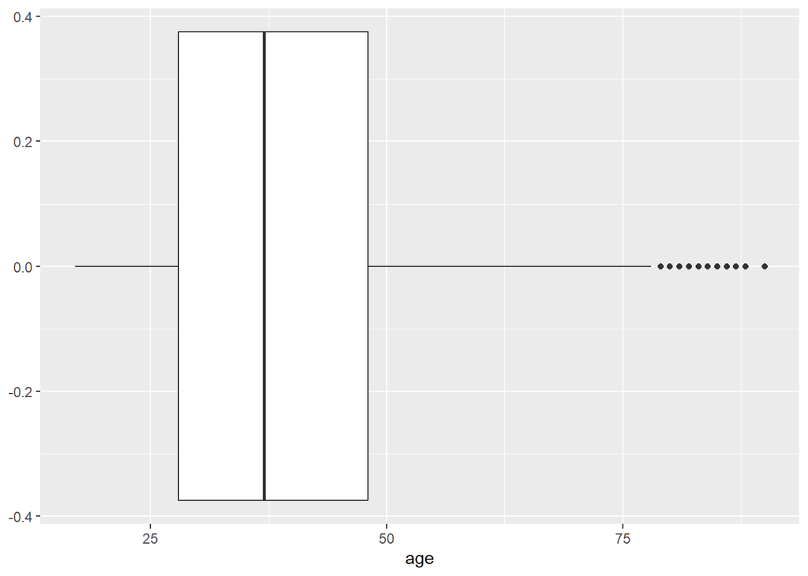

```r
df %>% ggplot()+
  geom_boxplot(mapping = aes(x = age))
```

```r
#We can conclude that the median age in our data set is just below 37.5 as the middle line in our boxplot is just to the left of this value. This suggests that approximately half of the ages in our data are below this value and the approximately the other half are above. The boxplot also allows us to expand our understanding of the outliers in our data enabling us to see the individual data points (10) included in this data set.
```

2. For one categorical variable
- Barplot

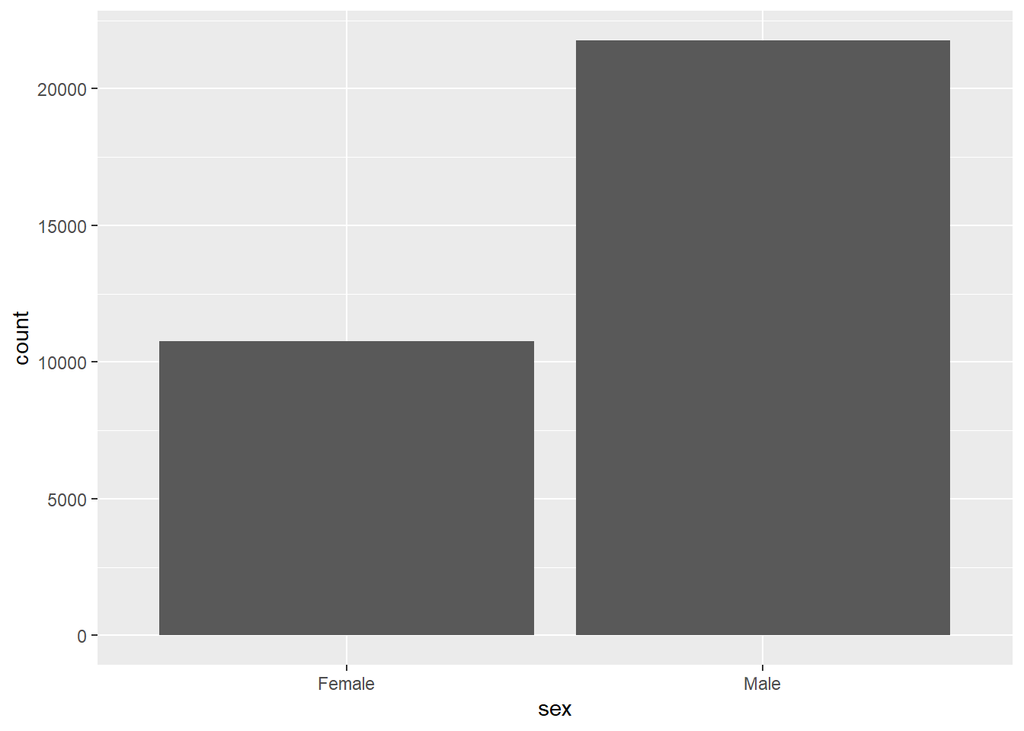

```r
df %>%
  filter(sex %in% c("Male", "Female")) %>%
  ggplot()+
  geom_bar(mapping = aes(x = sex))
```

```r
#The barplot of the variable sex shows that more of the individuals in our census data set were recorded as males rather than females when filtering out data where the variable sex was unreported.
```

3. For two continuous variables
- Scatter Plot

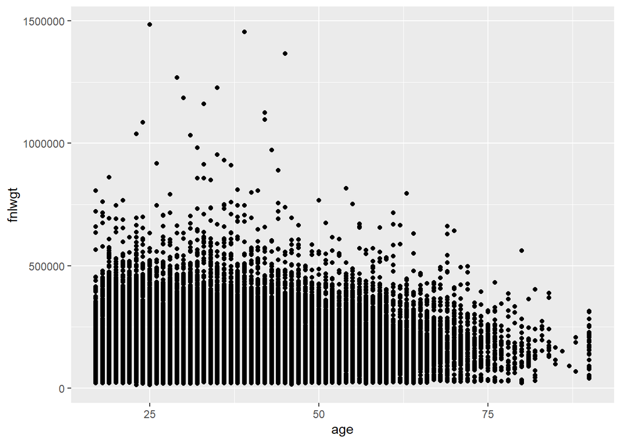

```r
df %>%
  ggplot()+geom_point(aes(x = age, y = fnlwgt))
```

```r
#If we were to try to put a line of best fit into this scatter plot, we could say that there appears to be a negative correlation between the variables age and fnlwgt for this census data set. This suggests that age increases, the number of people the census believes the entry represents decreases.
```

- Line Plot

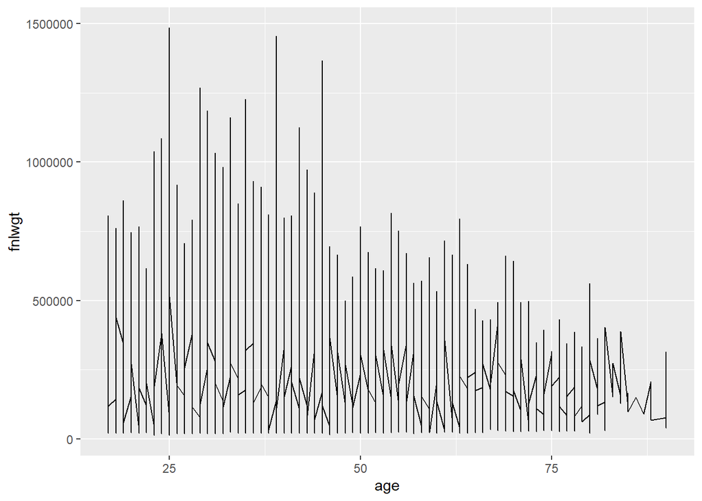

```r
df %>%
  ggplot() +
  geom_line(aes(x = age, y = fnlwgt))
```

```r
#We should also note this line graph has significant variability. The variable fnlwgt values for the various age groups are more spread suggesting there may not be a consistent relationship between these two variables. Some observations to note about this geom include the line plot of these variables suggests that from approximately the ages of 25 to 50, the variable fnlwgt is higher suggestive that for this age range, the number of people the census is representative of may be higher. This line plot slopes downward after age 50 suggesting that as the age variable increases in the data set, the variable fnlwgt decreases.
```

- Smooth Plot

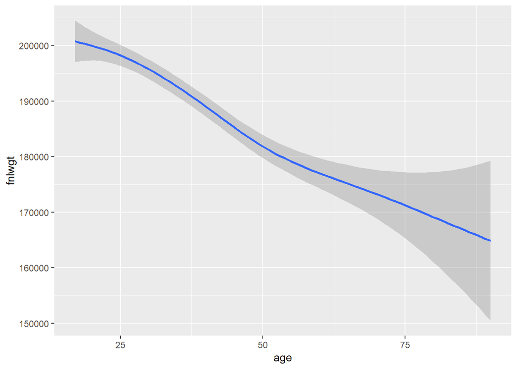

```r
df %>% ggplot()+geom_smooth(aes(x=age, y=fnlwgt))
```

```r
#The smooth plot of these variables enables us to see that the smooth line has slight curve while still trending in a negative direction. The smooth plot is suggestive of a non-linear relationship between age and fnlwgt because the smooth line has some areas in which it curves.
```

4. For one continuous + one categorical variables
- Density

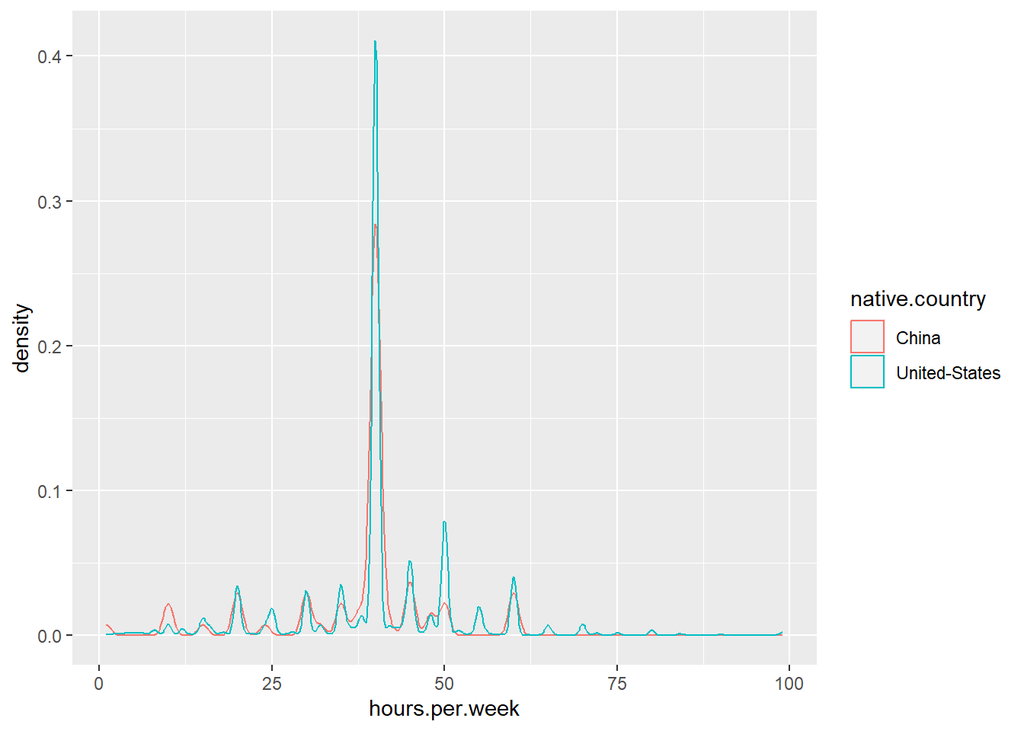

```r
df %>%
  filter(native.country %in% c("United-States", "China")) %>%
  ggplot() +
  geom_density(mapping = aes(x = hours.per.week, color = native.country))
```